# 第一篇 数据与分析

## 数据分析方法

- 普遍的"相关性"–身高体重与股价

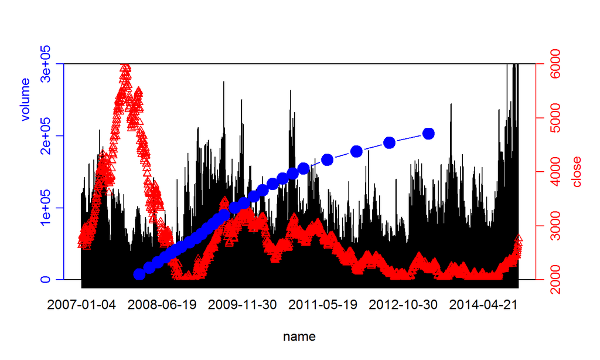

```r
n=nrow(SSEC);x=1:n;y1=SSEC$SSEC.Volum;y2=SSEC$SSEC.Close;
twoord.plot(x,y1,x,y2,xlim=c(0,n),lylim=c(0,300000),rylim=c(2000,6000), lcol=4,rcol=2,xlab="name",ylab="volume",rylab="close",type=c("bar","b"),xticklab=SSEC$t,halfwidth=0.2)
plot(身高~体重,d2,axes=F,col="blue",pch=19,type='b',cex=2,xlab='',ylab='')
```

## 数据分析方法

- 一步到位的分析（很相关）

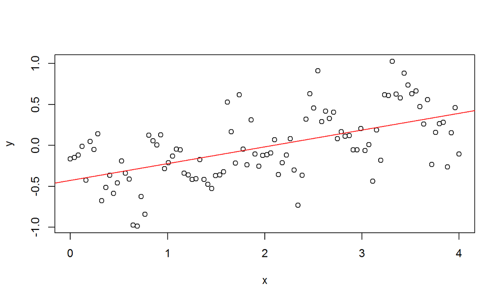

```r
plot(x, y)
abline(lm(y ~ x), col = "red")
```

## 数据分析方法

- 一步到位的分析（逆袭–控制变量）

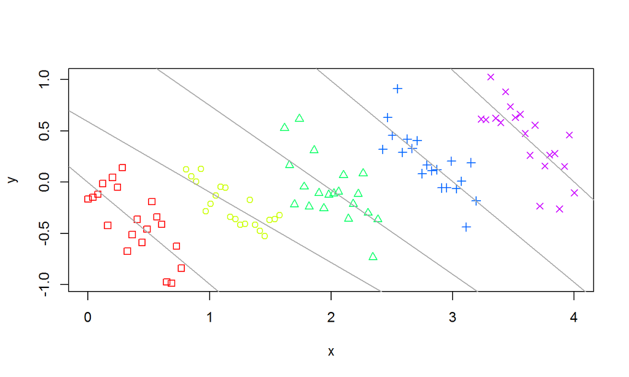

```r
plot(x, y, pch = z, col = rainbow(5)[z + 1])
for (i in z) abline(lm(y ~ x, subset = z == i), col = "darkgray")
```

## 数据分析方法

+——-+——+——+  
| 统计 | 有效| 无效 |  
+——-+——+——+  
| 新药 | 80 | 120 |  
+——-+——+——+  
| 安慰剂| 100 | 100 |  
+——-+——+——+  
RD = 80/200-100/200= -0.1

```
| 性别 |   男性  |   女性  |
| ---- | -- | -- | -- | -- |
|      |有效|无效|有效|无效|
| ---- | -- | -- | -- | -- |
| 新药 | 35 |15  |45  |105 |  RD男 = 35/50-90/150= 0.1
|安慰剂| 90 |60  |10  |40  |  RD女 = 45/150-10/50= 0.1
```

- 辛普森悖论

## 数据分析方法

- 辛普森悖论2

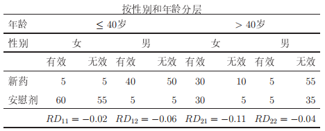

## 数据分析方法

1. 分析与观察
2. 统计建模
3. 数据挖掘
4. 分析工具

## 方法–1.分析与观察

最常用的图形

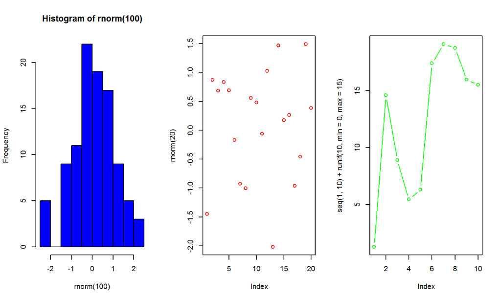

```r
par(mfrow = c(1, 3));
hist(rnorm(100),col='blue');plot(rnorm(20),col='red');
plot(seq(1,10)+runif(10,min=0,max=15),type='b',col='green')
```

## 方法–1.分析与观察 最常用的工具  
excel图表

[figure not shown]

## 方法–1.分析与观察

复杂的图形

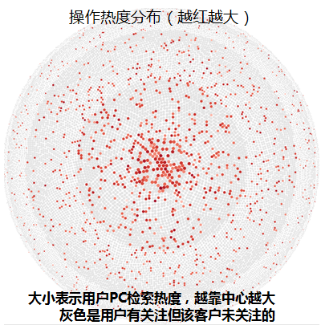

## 方法–1.分析与观察

复杂的图形-艺术与设计

[figure not shown]

## 方法–2.统计建模

- 抽样
- 假设
- 估计
- 理论

## 方法–3.数据挖掘

- 输入
- 算法
- 输出
- 评估
- 工程

## 方法–4.分析工具

Magic Quadrant for Business Intelligence and Analytics Platforms. by [gartner](http://www.gartner.com/technology/reprints.do?id=1-1QLGACN&ct=140210&st=sb)

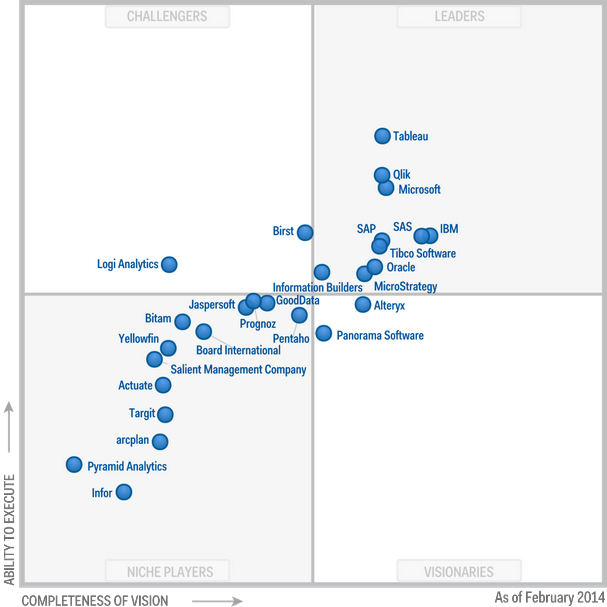

excel, SPSS, SAS, matlab, R, weka, python, … …

## 数据>分析>方法–小结

- 兴趣+观察+分析
- 统计建模
- 数据挖掘
- 代码流
- 工具流

因地制宜，发挥所长。

## 参考

[1]:谢益辉,2010,"统计图形和模拟视角下的模型理论解析".  
[2]:达莱尔,廖颖林译,2002,《统计陷阱》.  
[3]:耿直,2009,"如何从生命科学研究数据中挖掘因果关系和评价因果作用？"  
[4]:刘德寰,李雪莲,2013,"大数据的风险和现存问题"